# Deep into MRI

I want to really tailor a given classifier to the MRI data, and try several different feature selection methods. Mostly because other people have shown that the classification is indeed possible, so we can try to at least replicate those ideas.

Let’s stick to a single classifier, and really tailor the parameter grid search to the data. We should also play with the different ways to do feature selection.

```r
# for replication purposes
set.seed(107)
source('~/ncr_notebooks/baseline_prediction//src/aux_functions.R')
# Philip pre-selected which structural scans to use
gf_fname = '~/data/baseline_prediction/structural_match_02092017.csv'
data_fname = '~/data/baseline_prediction/structural_long_02092017.csv'
gf = read.csv(gf_fname)
group_var = 'DX2'
data = read.csv(data_fname)
maskid_gf = unique(gf[, c('MASKID', group_var)])
ldata = merge(maskid_gf, data, by.x='MASKID', by.y='lh.aparc.thickness', all.y = F)
eval(parse(text=sprintf('groups = ldata$\"%s\"', group_var)))
idx = groups=='NV' | groups=='ADHD'
groups = factor(groups[idx])
ldata = ldata[idx,]
```

As usual, let’s start by throwing everything in there, and then start doing it by domains:

# All data

```r
phen_vars = c(which(grepl("_thickness$", colnames(ldata))),
              which(grepl("_volume$", colnames(ldata))),
              which(grepl("_area$", colnames(ldata))),
              which(grepl("^Left.", colnames(ldata))),
              which(grepl("^Right.", colnames(ldata)))
              )
# remove WM variables
idx = phen_vars < 261 | phen_vars > 266
phen_vars = phen_vars[idx]
ldata = ldata[, phen_vars]
```

Let’s start with some baseline result to improve upon. I’ll go with random forests for now because it runs quite fast, and the number of parameters to optimize is not too high.

```r
# Create model with default paramters
x = ldata
y = groups
control <- trainControl(method="repeatedcv", number=10, repeats=3)
seed <- 7
metric <- "Accuracy"
set.seed(seed)
mtry <- sqrt(ncol(x))
tunegrid <- expand.grid(.mtry=mtry)
rf_default <- train(y~., data=x, method="rf", metric=metric, tuneGrid=tunegrid, trControl=control,
                    preProcess = c('center', 'scale'))
print(rf_default)
```

```
Random Forest

237 samples
235 predictors
  2 classes: 'ADHD', 'NV'

Pre-processing: centered (236), scaled (236)
Resampling: Cross-Validated (10 fold, repeated 3 times)
Summary of sample sizes: 213, 213, 214, 213, 213, 214, ...
Resampling results:

  Accuracy   Kappa
  0.5785676  0.08982204

Tuning parameter 'mtry' was held constant at a value of 15.36229
```

Random search on mtry:

```r
# Random Search
control <- trainControl(method="repeatedcv", number=10, repeats=3, search="random")
set.seed(seed)
mtry <- sqrt(ncol(x))
rf_random <- train(y~., data=x, method="rf", metric=metric, tuneLength=15, trControl=control)
print(rf_random)
```

```
Random Forest

237 samples
235 predictors
  2 classes: 'ADHD', 'NV'

No pre-processing
Resampling: Cross-Validated (10 fold, repeated 3 times)
Summary of sample sizes: 213, 213, 214, 213, 213, 214, ...
Resampling results across tuning parameters:

  mtry  Accuracy   Kappa
   14   0.5655338  0.05885226
   48   0.5555797  0.04489303
   83   0.5658357  0.07162437
   88   0.5740531  0.08463123
   91   0.5740531  0.08516678
  134   0.5823261  0.10834373
  146   0.5684420  0.08062545
  158   0.5839010  0.10951042
  162   0.5727754  0.08787958
  166   0.5797343  0.09890372
  175   0.5641546  0.06869650
  188   0.5741232  0.08447505
  194   0.5797850  0.10123325
  199   0.5814203  0.10231296
  232   0.5780435  0.09627640

Accuracy was used to select the optimal model using  the largest value.
The final value used for the model was mtry = 158.
```

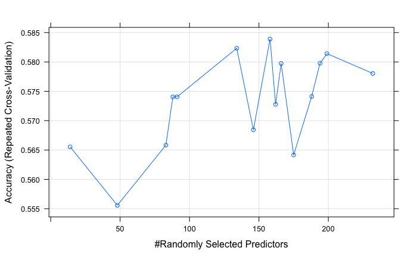

```r
plot(rf_random)
```

Grid search on mtry:

```r
control <- trainControl(method="repeatedcv", number=10, repeats=3, search="grid")
set.seed(seed)
tunegrid <- expand.grid(.mtry=c(1:15))
rf_gridsearch <- train(y~., data=x, method="rf", metric=metric, tuneGrid=tunegrid, trControl=control)
print(rf_gridsearch)
```

```
Random Forest

237 samples
235 predictors
  2 classes: 'ADHD', 'NV'

No pre-processing
Resampling: Cross-Validated (10 fold, repeated 3 times)
Summary of sample sizes: 213, 213, 214, 213, 213, 214, ...
Resampling results across tuning parameters:

  mtry  Accuracy   Kappa
   1    0.5684928  0.03841191
   2    0.5584783  0.02254894
   3    0.5608986  0.03165078
   4    0.5668720  0.04337425
   5    0.5797295  0.07875866
   6    0.5599831  0.03970635
   7    0.5737560  0.07276364
   8    0.5779879  0.07410214
   9    0.5782754  0.07821725
  10    0.5585942  0.03680114
  11    0.5724275  0.06765456
  12    0.5658454  0.05431165
  13    0.5585338  0.04324176
  14    0.5527923  0.02872860
  15    0.5669179  0.05604008

Accuracy was used to select the optimal model using  the largest value.
The final value used for the model was mtry = 5.
```

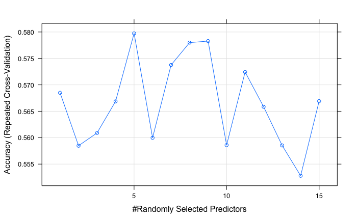

```r
plot(rf_gridsearch)
```

Or we can use the random forest own tuning function:

```
mtry = 15  OOB error = 45.15%
Searching left ...
mtry = 10   OOB error = 44.3%
0.01869159 1e-05
mtry = 7    OOB error = 47.68%
-0.07619048 1e-05
Searching right ...
mtry = 22   OOB error = 41.77%
0.05714286 1e-05
mtry = 33   OOB error = 44.3%
-0.06060606 1e-05
```

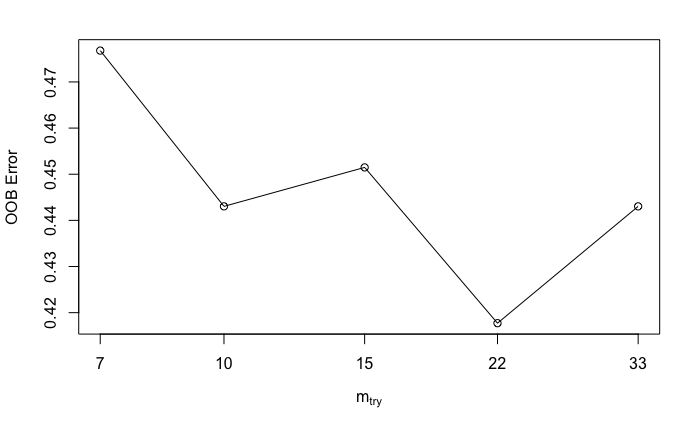

```r
# Algorithm Tune (tuneRF)
set.seed(seed)
bestmtry <- tuneRF(x, y, stepFactor=1.5, improve=1e-5, ntreeTry=1000)
```

```r
print(bestmtry)
```

```
       mtry  OOBError
7.OOB     7 0.4767932
10.OOB   10 0.4430380
15.OOB   15 0.4514768
22.OOB   22 0.4177215
33.OOB   33 0.4430380
```

Or we can try a few different values to see what’s the best value of mtry given different ntrees… But let’s play with other methods of feature selection first:

REMEMBER THAT WE’LL NEED TO DO THIS IN TRAINING DATA ONLY!

So, for example:

```r
ctrl = trainControl(method="repeatedcv", number=10, repeats=5, selectionFunction = "tolerance")
in_train = createDataPartition(groups, p=.75, list=FALSE)
trf = train(x, y, method="rf", metric="Kappa", trControl=ctrl, subset = in_train)
print(trf)
```

```
Random Forest

237 samples
236 predictors
  2 classes: 'ADHD', 'NV'

No pre-processing
Resampling: Cross-Validated (10 fold, repeated 5 times)
Summary of sample sizes: 214, 214, 213, 214, 212, 214, ...
Resampling results across tuning parameters:

  mtry  Accuracy   Kappa
    2   0.5625043  0.03293686
  119   0.5685638  0.07349632
  236   0.5660942  0.07291819

Kappa was used to select the optimal model using  a tolerance rule.
The final value used for the model was mtry = 119.
```

But of course, we’d define a finer grid up there. We could even compare it to an xgbTree model:

```r
xgb = train(x, y, method="xgbTree", metric="Kappa", trControl=ctrl, subset = in_train)
resampls = resamples(list(RF = trf,
                          XGB = xgb))
difValues = diff(resampls)
summary(difValues)
```

```
Call:
summary.diff.resamples(object = difValues)

p-value adjustment: bonferroni
Upper diagonal: estimates of the difference
Lower diagonal: p-value for H0: difference = 0

Accuracy
    RF     XGB
RF         0.006554
XGB 0.7362

Kappa
    RF     XGB
RF         -0.01758
XGB 0.6679
```

And make a few plots:

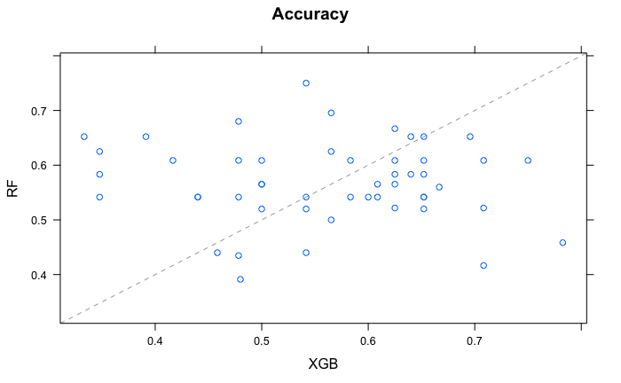

```r
xyplot(resampls)
```

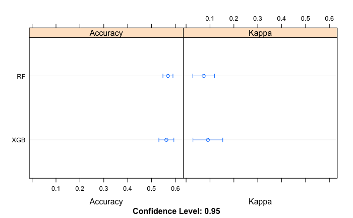

```r
dotplot(resampls)
```

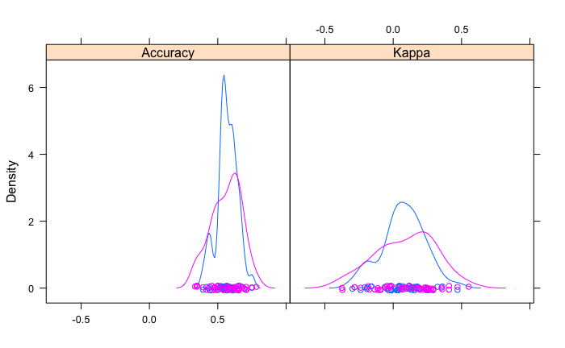

```r
densityplot(resampls)
```

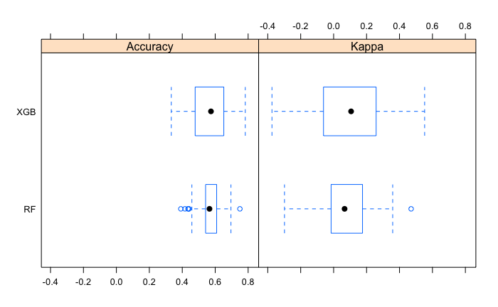

```r
bwplot(resampls)
```

But let’s stop playing around, and try some other types of features selection.

Univariate selection

RFE

```r
subsets <- c(1:5, 10, 15, 20, 25)
rfe_ctl <- rfeControl(functions = rfFuncs,
                   method = "repeatedcv",
                   repeats = 5,
                   verbose = FALSE)
rf_RFE <- rfe(x, y, sizes = subsets, rfeControl = rfe_ctl)
rf_RFE
```

```
Recursive feature selection

Outer resampling method: Cross-Validated (10 fold, repeated 5 times)

Resampling performance over subset size:

 Variables Accuracy    Kappa AccuracySD KappaSD Selected
         1   0.4723 -0.06890    0.09171  0.1877
         2   0.4897 -0.04702    0.09671  0.2041
         3   0.5040 -0.02813    0.09283  0.1869
         4   0.5257  0.01624    0.08922  0.1825
         5   0.5363  0.03427    0.08346  0.1763
        10   0.5372  0.03557    0.08602  0.1789
        15   0.5525  0.06191    0.07982  0.1650
        20   0.5510  0.05800    0.08078  0.1675
        25   0.5704  0.09619    0.08535  0.1834        *
       236   0.5683  0.06241    0.07230  0.1529

The top 5 variables (out of 25):
   rh_lingual_thickness, rh_superiortemporal_volume, lh_transversetemporal_thickness, Left.VentralDC, Left.Inf.Lat.Vent
```

Genetic

```r
ga_ctrl <- gafsControl(functions = rfGA,
                       method = "repeatedcv",
                       repeats = 5)
set.seed(10)
rf_ga <- gafs(x = x, y = y,
              iters = 100,
              gafsControl = ga_ctrl)
```

Annealing

```r
sa_ctrl <- safsControl(functions = rfSA,
                       method = "repeatedcv",
                       repeats = 5,
                       improve = 50)
set.seed(10)
rf_sa <- safs(x = x, y = y,
              iters = 100,
              safsControl = sa_ctrl)
```

Of course, it could be that those other papers were using adult data, so maybe if we factor out age (and sex)?